# **TFM: Feature Engineering**

Roberto Jesús Alcaraz Molina

14/04/2021

# Code

```r
insurance <- readRDS("insurance.RDS")
insurance_mortality <- readRDS("insurance_mortality.RDS")
insurance_lapse <- readRDS("insurance_lapse.RDS")
```

In this step of the project, we will analyze the following things:

- Variable selection through drop (p-value > 0.2).
- Interaction between variables.
- Preprocessing steps taking into account the EDA.

# Variable selection

First of all, before doing any interaction between all the variables, we will fit a simple logistic regression model to see which variables have an effect on the outcome and which does not, removing those whose p-value is greater than 0.2.

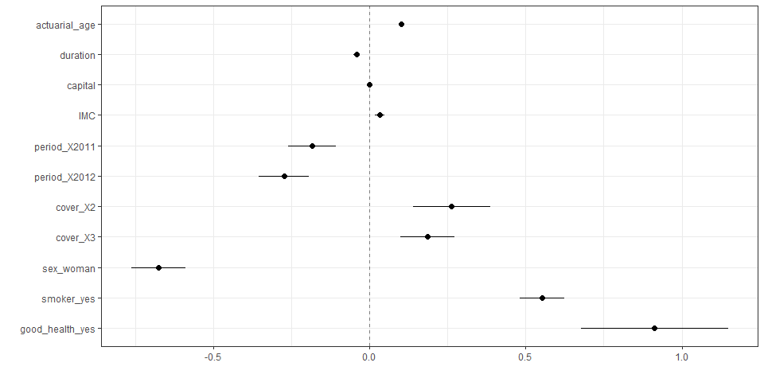

```r
rec <-
  recipe(mortality ~ period + cover + sex + smoker + good_health + actuarial_age + duration + capital + IMC,
         data = insurance) %>%
  themis::step_upsample(mortality, over_ratio = 0.01) %>%
  step_dummy(all_nominal_predictors())

# Model
glm_model <- logistic_reg() %>%
  set_engine("glm")

# Workflow
glm_wflow <- workflow() %>%
  add_model(glm_model) %>%
  add_recipe(rec)

# Fit
glm_fit <- fit(glm_wflow, insurance)
tidy(glm_fit) %>%
  # filter(p.value > 0.2) %>%
  dwplot(dot_args = list(size = 2, color = "black"),
         whisker_args = list(color = "black"),
         vline = geom_vline(xintercept = 0, colour = "grey50", linetype = 2))
```

```r
## Also, we are going to fit the same model with in the traditional way to be able to do the drop1
glm_drop <- glm(mortality ~ period + cover + sex + smoker + good_health + actuarial_age + duration + capital + IMC, data = insurance, family = "binomial")

drop1(glm_drop, test = "LRT")

# Single term deletions
#
# Model:
# mortality ~ period + cover + sex + smoker + good_health + actuarial_age +
#     duration + capital + IMC
#               Df Deviance    AIC     LRT  Pr(>Chi)
# <none>             4069.0 4093.0
# period         2   4072.0 4092.0   2.961 0.2275521
# cover          2   4070.3 4090.3   1.279 0.5275235
# sex            1   4084.4 4106.4  15.398 8.709e-05 ***
# smoker         1   4083.5 4105.5  14.431 0.0001454 ***
# good_health    1   4072.2 4094.2   3.112 0.0777260 .
# actuarial_age  1   4252.6 4274.6 183.597 < 2.2e-16 ***
# duration       1   4073.0 4095.0   3.912 0.0479543 *
# capital        1   4070.2 4092.2   1.124 0.2890350
# IMC            1   4069.7 4091.7   0.700 0.4028424
# ---
# Signif. codes:  0 ‘***’ 0.001 ‘**’ 0.01 ‘*’ 0.05 ‘.’ 0.1 ‘ ’ 1


drop1(update(glm_drop, as.formula(paste(".~.- cover"))), test = "LRT")
drop1(update(glm_drop, as.formula(paste(".~.- cover - IMC"))), test = "LRT")
drop1(update(glm_drop, as.formula(paste(".~.- cover - IMC - capital"))), test = "LRT")
drop1(update(glm_drop, as.formula(paste(".~.- cover - IMC - capital - period"))), test = "LRT")

# Single term deletions
#
# Model:
# mortality ~ sex + smoker + good_health + actuarial_age + duration
#               Df Deviance    AIC     LRT  Pr(>Chi)
# <none>             4075.2 4087.2
# sex            1   4098.9 4108.9  23.678 1.139e-06 ***
# smoker         1   4090.5 4100.5  15.332 9.017e-05 ***
# good_health    1   4077.3 4087.3   2.167     0.141
# actuarial_age  1   4276.2 4286.2 200.996 < 2.2e-16 ***
# duration       1   4079.4 4089.4   4.176     0.041 *
# ---
# Signif. codes:  0 ‘***’ 0.001 ‘**’ 0.01 ‘*’ 0.05 ‘.’ 0.1 ‘ ’ 1
```

### Inferential model

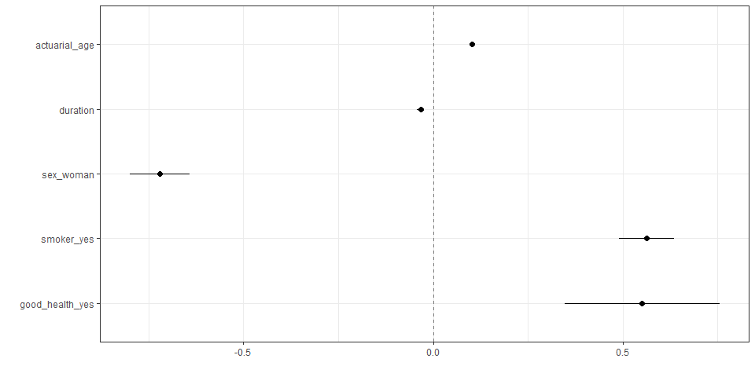

```r
set.seed(23)
# Recipe
rec <-
  recipe(mortality ~ sex + smoker + good_health + actuarial_age + duration,
         data = insurance) %>%
  themis::step_upsample(mortality, over_ratio = 0.01) %>%
  step_dummy(all_nominal_predictors())

# Model
glm_model <- logistic_reg() %>%
  set_engine("glm")

# Workflow
glm_wflow <- workflow() %>%
  add_model(glm_model) %>%
  add_recipe(rec)

glm_fit <- fit(glm_wflow, insurance)
tidy(glm_fit) %>%
  dwplot(dot_args = list(size = 2, color = "black"),
         whisker_args = list(color = "black"),
         vline = geom_vline(xintercept = 0, colour = "grey50", linetype = 2))
```

```r
# We can get also the odds ratio
tidy(glm_fit) %>%
  mutate(
    odds_ratio = exp(estimate)
  ) %>%
  select(term, odds_ratio)
```

| term | odds_ratio |
| --- | --- |
| (Intercept) | 7.937065e-05 |
| actuarial_age | 1.106556e+00 |
| duration | 9.670525e-01 |
| sex_woman | 4.862270e-01 |
| smoker_yes | 1.755447e+00 |
| good_health_yes | 1.733718e+00 |

Now, if we change the variables `IMC` and `capital` for their transformed variables, we can see if our inferential model could explain better.

```r
## Also, we are going to fit the same model with in the traditional way to be able to do the drop1
glm_drop <- glm(mortality ~ period + cover + sex + smoker + good_health + actuarial_age + duration + capital_factor_2 + IMC_factor_1, data = insurance, family = "binomial")

drop1(glm_drop, test = "LRT")

# Single term deletions
#
# Model:
# mortality ~ period + cover + sex + smoker + good_health + actuarial_age +
#     duration + capital_factor_2 + IMC_factor_1
#                  Df Deviance    AIC     LRT  Pr(>Chi)
# <none>                4067.8 4093.8
# period            2   4070.7 4092.7   2.867 0.2384699
# cover             2   4069.0 4091.0   1.162 0.5592091
# sex               1   4084.2 4108.2  16.351 5.262e-05 ***
# smoker            1   4082.2 4106.2  14.428 0.0001456 ***
# good_health       1   4070.9 4094.9   3.122 0.0772596 .
# actuarial_age     1   4250.2 4274.2 182.341 < 2.2e-16 ***
# duration          1   4072.0 4096.0   4.224 0.0398630 *
# capital_factor_2  2   4068.1 4090.1   0.296 0.8625111
# IMC_factor_1      1   4070.6 4094.6   2.770 0.0960468 .
# ---
# Signif. codes:  0 ‘***’ 0.001 ‘**’ 0.01 ‘*’ 0.05 ‘.’ 0.1 ‘ ’ 1

drop1(update(glm_drop, as.formula(paste(".~.- capital_factor_2"))), test = "LRT")
drop1(update(glm_drop, as.formula(paste(".~.- capital_factor_2 - cover"))), test = "LRT")
drop1(update(glm_drop, as.formula(paste(".~.- capital_factor_2 - cover - period"))), test = "LRT")

# Single term deletions
#
# Model:
# mortality ~ sex + smoker + good_health + actuarial_age + duration +
#     IMC_factor_1
#               Df Deviance    AIC     LRT  Pr(>Chi)
# <none>             4072.3 4086.3
# sex            1   4089.2 4101.2  16.887 3.967e-05 ***
# smoker         1   4087.5 4099.5  15.121 0.0001008 ***
# good_health    1   4075.4 4087.4   3.045 0.0809905 .
# actuarial_age  1   4260.7 4272.7 188.315 < 2.2e-16 ***
# duration       1   4076.3 4088.3   3.980 0.0460408 *
# IMC_factor_1   1   4075.2 4087.2   2.845 0.0916580 .
# ---
# Signif. codes:  0 ‘***’ 0.001 ‘**’ 0.01 ‘*’ 0.05 ‘.’ 0.1 ‘ ’ 1
```

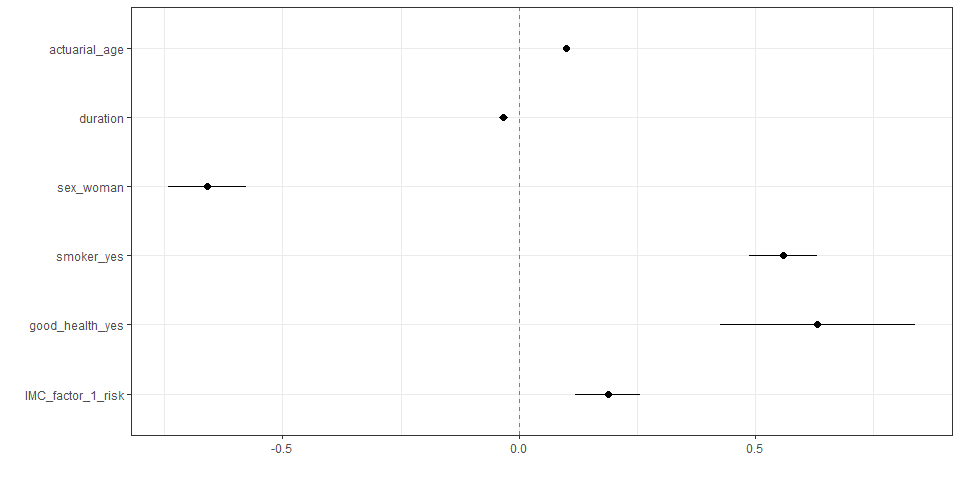

```r
set.seed(23)
# Recipe
rec <-
  recipe(mortality ~ sex + smoker + good_health + actuarial_age + duration + IMC_factor_1,
         data = insurance) %>%
  themis::step_upsample(mortality, over_ratio = 0.01) %>%
  step_dummy(all_nominal_predictors())

# Model
glm_model <- logistic_reg() %>%
  set_engine("glm")

# Workflow
glm_wflow <- workflow() %>%
  add_model(glm_model) %>%
  add_recipe(rec)

glm_fit <- fit(glm_wflow, insurance)
tidy(glm_fit) %>%
  dwplot(dot_args = list(size = 2, color = "black"),
         whisker_args = list(color = "black"),
         vline = geom_vline(xintercept = 0, colour = "grey50", linetype = 2))
```

```r
tidy(glm_fit) %>%
  mutate(
    odds_ratio = exp(estimate)
  ) %>%
  select(term, odds_ratio)
```

| term | odds_ratio |
| --- | --- |
| (Intercept) | 6.991004e-05 |
| actuarial_age | 1.105057e+00 |
| duration | 9.677489e-01 |
| sex_woman | 5.173999e-01 |
| smoker_yes | 1.749060e+00 |
| good_health_yes | 1.883154e+00 |
| IMC_factor_1_risk | 1.207790e+00 |

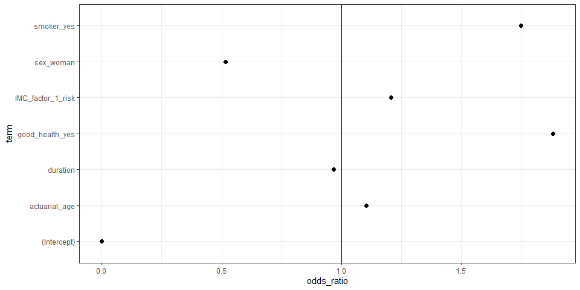

```r
tidy(glm_fit) %>%
  mutate(
    odds_ratio = exp(estimate)
  ) %>%
  select(term, odds_ratio) %>%
  ggplot(aes(x = odds_ratio, y = term)) +
  geom_point(size = 2) + geom_vline(xintercept = 1)
```

# Interaction terms

Now, our model is going to be formed by the variables sex, smoker, good_health, actuarial_age, duration and IMC_factor_1. Regarding the interactions, we can add interaction terms between two categorical variables, or between one categorical and one numerical.

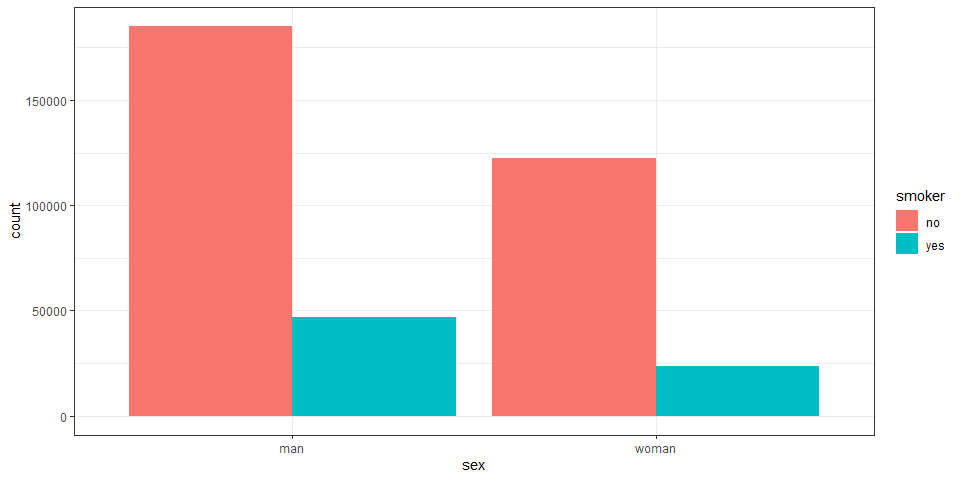

```r
# Interactions between the categorical variables:
insurance %>%
  ggplot(aes(x = sex, fill = smoker)) +
  geom_bar(position = "dodge")
```

```r
tab <- table(insurance$sex, insurance$smoker)*100/nrow(insurance)
cbind(tab, tab[, 2] / (tab[, 1] + tab[, 2]))
```

```
##             no       yes
## man   48.96908 12.360449 0.2015416
## woman 32.42911  6.241365 0.1613987
```

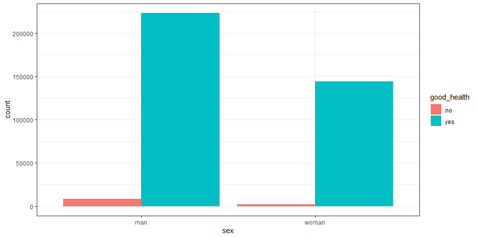

```r
insurance %>%
  ggplot(aes(x = sex, fill = good_health)) +
  geom_bar(position = "dodge")
```

```r
tab <- table(insurance$sex, insurance$good_health)*100/nrow(insurance)
cbind(tab, tab[, 2] / (tab[, 1] + tab[, 2]))
```

```
##              no      yes
## man   2.2751695 59.05436 0.9629025
## woman 0.4891244 38.18135 0.9873515
```

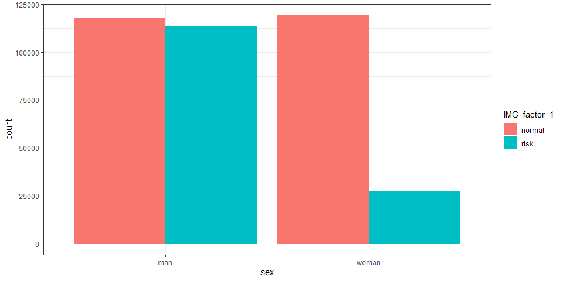

```r
insurance %>%
  ggplot(aes(x = sex, fill = IMC_factor_1)) +
  geom_bar(position = "dodge")
```

```r
tab <- table(insurance$sex, insurance$IMC_factor_1)*100/nrow(insurance)
cbind(tab, tab[, 2] / (tab[, 1] + tab[, 2]))
```

```
##         normal      risk
## man   31.24547 30.084062 0.4905314
## woman 31.53158  7.138887 0.1846082
```

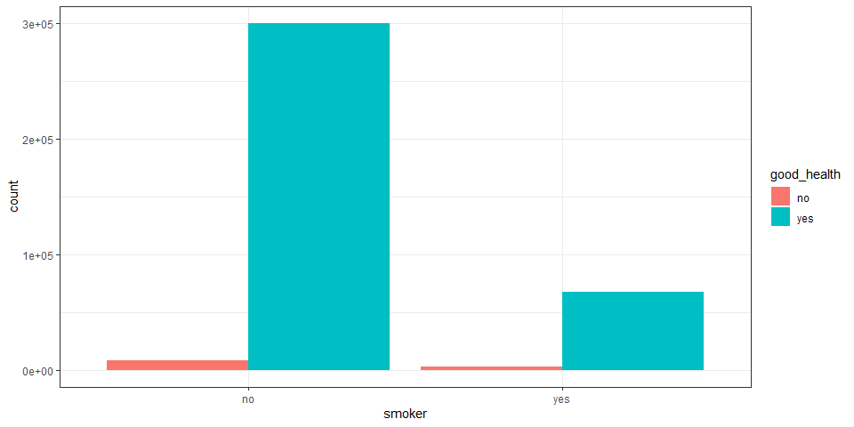

```r
insurance %>%
  ggplot(aes(x = smoker, fill = good_health)) +
  geom_bar(position = "dodge")
```

```r
tab <- table(insurance$smoker, insurance$good_health)*100/nrow(insurance)
cbind(tab, tab[, 2] / (tab[, 1] + tab[, 2]))
```

```
##            no      yes
## no  2.0435765 79.35461 0.9748941
## yes 0.7207174 17.88110 0.9612555
```

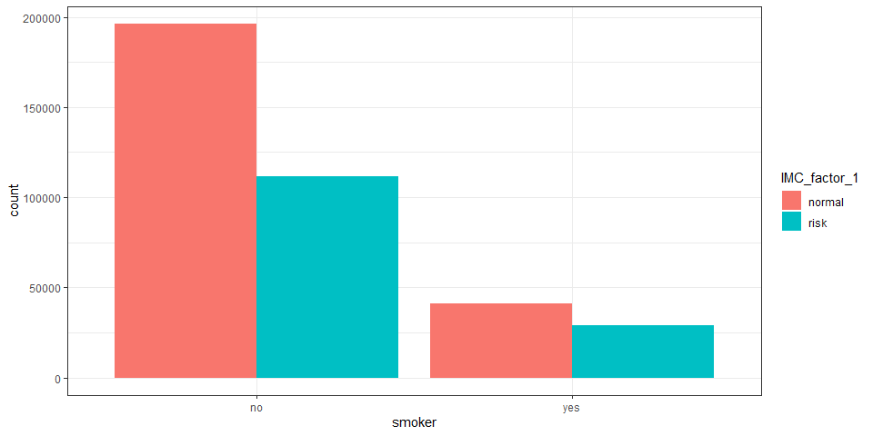

```r
insurance %>%
  ggplot(aes(x = smoker, fill = IMC_factor_1)) +
  geom_bar(position = "dodge")
```

```r
tab <- table(insurance$smoker, insurance$IMC_factor_1)*100/nrow(insurance)
cbind(tab, tab[, 2] / (tab[, 1] + tab[, 2]))
```

```
##       normal      risk
## no  51.91044 29.487743 0.3622654
## yes 10.86661  7.735206 0.4158307
```

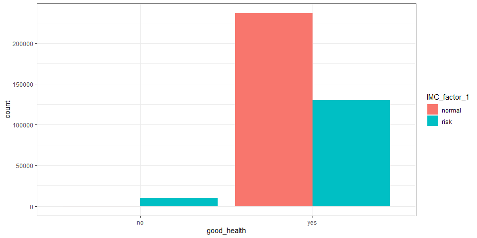

```r
insurance %>%
  ggplot(aes(x = good_health, fill = IMC_factor_1)) +
  geom_bar(position = "dodge")
```

```r
tab <- table(insurance$good_health, insurance$IMC_factor_1)*100/nrow(insurance)
cbind(tab, tab[, 2] / (tab[, 1] + tab[, 2]))
```

```
##          normal      risk
## no   0.02461503  2.739679 0.9910954
## yes 62.75243636 34.483270 0.3546359
```

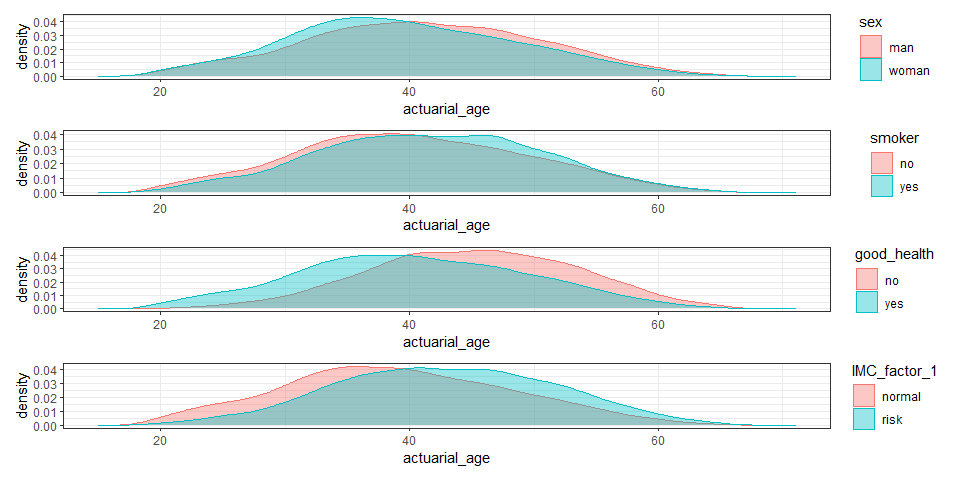

```r
# Interactions between actuarial_age and the categorical variables:
a <- insurance %>%
  ggplot(aes(x = actuarial_age, color = sex, fill = sex)) +
  geom_density(alpha = 0.4)
b <- insurance %>%
  ggplot(aes(x = actuarial_age, color = smoker, fill = smoker)) +
  geom_density(alpha = 0.4)
c <- insurance %>%
  ggplot(aes(x = actuarial_age, color = good_health, fill = good_health)) +
  geom_density(alpha = 0.4)
d <- insurance %>%
  ggplot(aes(x = actuarial_age, color = IMC_factor_1, fill = IMC_factor_1)) +
  geom_density(alpha = 0.4)

a / b / c / d
```

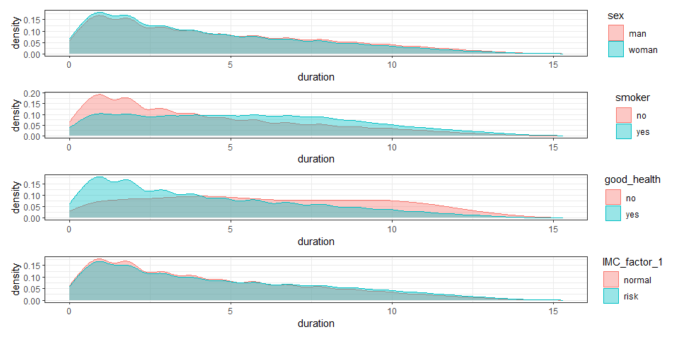

```r
# Interactions between duration and the categorical variables:
a <- insurance %>%
  ggplot(aes(x = duration, color = sex, fill = sex)) +
  geom_density(alpha = 0.4)
b <- insurance %>%
  ggplot(aes(x = duration, color = smoker, fill = smoker)) +
  geom_density(alpha = 0.4)
c <- insurance %>%
  ggplot(aes(x = duration, color = good_health, fill = good_health)) +
  geom_density(alpha = 0.4)
d <- insurance %>%
  ggplot(aes(x = duration, color = IMC_factor_1, fill = IMC_factor_1)) +
  geom_density(alpha = 0.4)

a / b / c / d
```

```r
max_model <- glm(mortality ~ (sex + smoker + good_health + actuarial_age + duration + IMC_factor_1)^2 - actuarial_age:duration, # no interaction between numerical
                 data = insurance,
                 family = "binomial")

min_model <- glm(mortality ~ 1, data = insurance, family = "binomial")

step_model <- stats::step(max_model,
                          direction = "backward",
                          scope = list(upper = max_model, lower = min_model),
                          trace = 0)
summary(step_model)

# Call:
# glm(formula = mortality ~ sex + smoker + good_health + actuarial_age +
#     duration + IMC_factor_1 + sex:duration, family = "binomial",
#     data = insurance)
#
# Deviance Residuals:
#     Min       1Q   Median       3Q      Max
# -0.1909  -0.0416  -0.0283  -0.0192   4.3973
#
# Coefficients:
#                     Estimate Std. Error z value Pr(>|z|)
# (Intercept)       -12.206161   0.543400 -22.463  < 2e-16 ***
# sexwoman           -0.964857   0.269777  -3.577 0.000348 ***
# smokeryes           0.561524   0.137516   4.083 4.44e-05 ***
# good_healthyes      0.604104   0.388776   1.554 0.120217
# actuarial_age       0.101119   0.007618  13.274  < 2e-16 ***
# duration           -0.050428   0.020340  -2.479 0.013166 *
# IMC_factor_1risk    0.225319   0.132219   1.704 0.088356 .
# sexwoman:duration   0.068035   0.041226   1.650 0.098885 .
# ---
# Signif. codes:  0 ‘***’ 0.001 ‘**’ 0.01 ‘*’ 0.05 ‘.’ 0.1 ‘ ’ 1
#
# (Dispersion parameter for binomial family taken to be 1)
#
#     Null deviance: 4335.3  on 377817  degrees of freedom
# Residual deviance: 4069.7  on 377810  degrees of freedom
# AIC: 4085.7
#
# Number of Fisher Scoring iterations: 11
```